# Funkce

Zpracovávání výzkumných dat pomocí jazyka R

## Program

- kontrola domácího úkolu
- co je to programování v R?
- `if ... else`
- funkce `ifelse`
- cykly
- rodina `apply` funkcí
- závěrečný projekt

## Kontrola domácí práce

### Úloha 1

**Najděte specifickou funkci v balíčku dplyr, která umožňuji přepisování hodnot na `NA`.**

Funkce `na_if`.

Pomocí této funkce je možné porovnat dvě hodnoty; pokud jsou totožné, první z nich bude změněna na NA.

```r
x <- c(1, 3, 4, 5, 4, 8, 8)
y <- c(4)
dplyr::na_if(x, y)
```

```
[1]  1  3 NA  5 NA  8  8
```

### Úloha 2

```
1.  Kolik osob ve věku 18-26 včetně v Jihomoravském kraji jsou evidováni jako osoby bez domova, a jakou procentuální část z nich tvoří muži a jakou ženy.

2.  Který kraj má nejmenší počet obyvatel žijících v ubytovacích zařízení?

3.  Jaký je medián věku osoby bez domova v Praze, a jaký je v celé ČR?

4.  Jaký je nejčastější typ ubytování osob pod 18 let v ČR?

5.  O kolik více seniorů (65+ let) bez domova žije v Libereckém než v Moravskoslezském kraji či naopak?
```

Načteme a projdeme si dataset.

```r
library(tidyverse)
typBydleni <- read.csv("typBydleni.csv",
                       stringsAsFactors = TRUE)
str(typBydleni)
```

```
'data.frame':   34845 obs. of  19 variables:
 $ idhod          : int  989214475 989145591 989214804 989179221 989127848 989144844 989249176 989197612 989197183 989179220 ...
 $ hodnota        : int  109185 55778 53407 110950 56820 54130 112995 57808 55187 114439 ...
 $ ukaz_kod       : int  3162 3162 3162 3162 3162 3162 3162 3162 3162 3162 ...
 $ bydleni_cis    : int  3335 3335 3335 3335 3335 3335 3335 3335 3335 3335 ...
 $ bydleni_kod    : int  56 56 56 56 56 56 56 56 56 56 ...
 $ bydleni_cleneni: int  1 1 1 1 1 1 1 1 1 1 ...
 $ vek_cis        : int  1035 1035 1035 1035 1035 1035 1035 1035 1035 1035 ...
 $ vek_kod        : int  1000000000 1000000000 1000000000 1000010001 1000010001 1000010001 1000020002 1000020002 1000020002 1000030003 ...
 $ pohlavi_cis    : int  NA 102 102 NA 102 102 NA 102 102 NA ...
 $ pohlavi_kod    : int  NA 1 2 NA 1 2 NA 1 2 NA ...
 $ uzemi_cis      : int  97 97 97 97 97 97 97 97 97 97 ...
 $ uzemi_kod      : int  19 19 19 19 19 19 19 19 19 19 ...
 $ sldb_rok       : int  2021 2021 2021 2021 2021 2021 2021 2021 2021 2021 ...
 $ sldb_datum     : Factor w/ 1 level "2021-03-26": 1 1 1 1 1 1 1 1 1 1 ...
 $ ukaz_txt       : Factor w/ 1 level "Počet obyvatel s obvyklým pobytem": 1 1 1 1 1 1 1 1 1 1 ...
 $ bydleni_txt    : Factor w/ 5 levels "Bezdomovci","Byt",..: 3 3 3 3 3 3 3 3 3 3 ...
 $ vek_txt        : Factor w/ 101 levels "0 let","1 rok",..: 1 1 1 2 2 2 14 14 14 25 ...
 $ pohlavi_txt    : Factor w/ 3 levels "","muž","žena": 1 2 3 1 2 3 1 2 3 1 ...
 $ uzemi_txt      : Factor w/ 23 levels "Česká republika",..: 1 1 1 1 1 1 1 1 1 1 ...
```

```r
levels(typBydleni$bydleni_txt)
```

```
[1] "Bezdomovci"
[2] "Byt"
[3] "Obyvatelstvo podle způsobu bydlení celkem (kromě bezdomovců)"
[4] "Osoby žijící v jiných obydlích"
[5] "Osoby žijící v ubytovacím zařízení"
```

```r
#pozor, vidime ze s Prahou to nebude tak jednoduche
  #budeme si muset zjisit hodnoty podle ciselniku
levels(typBydleni$uzemi_txt)
```

```
 [1] "Česká republika"      "Hlavní město Praha"   "Jihočeský kraj"
 [4] "Jihomoravský kraj"    "Jihovýchod"           "Jihozápad"
 [7] "Karlovarský kraj"     "Kraj Vysočina"        "Královéhradecký kraj"
[10] "Liberecký kraj"       "Moravskoslezsko"      "Moravskoslezský kraj"
[13] "Olomoucký kraj"       "Pardubický kraj"      "Plzeňský kraj"
[16] "Praha"                "Severovýchod"         "Severozápad"
[19] "Střední Čechy"        "Střední Morava"       "Středočeský kraj"
[22] "Ústecký kraj"         "Zlínský kraj"
```

```r
levels(typBydleni$pohlavi_txt) #co je zac ""
```

```
[1] ""     "muž"  "žena"
```

Podívejme se blíže na sloupec pohlaví, jelikož s ním budeme pracovat. **Co jsou zač řádky s prázdnými hodnotami?**

```r
kontrola <- typBydleni %>%
  select(hodnota, pohlavi_txt, vek_txt) %>%
  head(); kontrola
```

```
  hodnota pohlavi_txt vek_txt
1  109185               0 let
2   55778         muž   0 let
3   53407        žena   0 let
4  110950               1 rok
5   56820         muž   1 rok
6   54130        žena   1 rok
```

```r
identical(kontrola[1, "hodnota"],
          sum(kontrola[2:3, "hodnota"]))
```

```
[1] TRUE
```

```r
identical(kontrola[4, "hodnota"],
          sum(kontrola[5:6, "hodnota"]))
```

```
[1] TRUE
```

**Tyto řádky očividně obsahují celkové hodnoty pro obě pohlaví** - to se nám bude hodit!

Pořád vám ale říkám, že bychom si to **neměli kontrolovat jen po oku**. Tak si na to rovnou napíšeme funkci ;].

```r
kontrola_pohlavi <- function(data) {
  vysledek <- data.frame(
    radek = integer(),
    hodnota_celkem = numeric(),
    soucet_pohlavi = numeric(),
    shoda = logical())

  for (i in 1:(nrow(data) - 2)) {
    if (data$pohlavi_txt[i] == "") {
      soucet <- sum(data$hodnota[(i + 1):(i + 2)])
      vysledek <- rbind(vysledek, data.frame(
        radek = i,
        hodnota_celkem = data$hodnota[i],
        soucet_pohlavi = soucet,
        shoda = data$hodnota[i] == soucet))
    }
  }
  return(vysledek)}

kontrola_pohlavi(typBydleni)
```

```
      radek hodnota_celkem soucet_pohlavi shoda
1         1         109185         109185  TRUE
2         4         110950         110950  TRUE
3         7         112995         112995  TRUE
4        10         114439         114439  TRUE
5        13         113054         113054  TRUE
6        16         112069         112069  TRUE
7        19         110939         110939  TRUE
8        22         108581         108581  TRUE
9        25         109116         109116  TRUE
10       28         109306         109306  TRUE
11       31         115770         115770  TRUE
12       34         119359         119359  TRUE
13       37         119635         119635  TRUE
14       40         117220         117220  TRUE
```

[output cut: 11601 more lines]

```r
kontrola_pohlavi(typBydleni) %>%
  filter(shoda == FALSE)
```

```
[1] radek          hodnota_celkem soucet_pohlavi shoda
<0 rows> (or 0-length row.names)
```

Upravme si dataframe tak, abychom s ním mohli pracovat.

```r
#dataset se vsemi moznostmi pohlavi
dataVsechnaPohlavi <- typBydleni %>%
  rename(pohlavi = pohlavi_txt,
         uzemi = uzemi_txt,
         vek = vek_txt,
         bydleni = bydleni_txt) %>%
  mutate(vek = parse_number(as.character(vek))) %>%
  select(hodnota, pohlavi, uzemi, bydleni, vek, uzemi_cis)

#dataset jenom pro vsechny
data <- dataVsechnaPohlavi %>%
  filter(pohlavi == "")
```

### 2.1

**Kolik osob ve věku 18-26 včetně v Jihomoravském kraji jsou evidováni jako osoby bez domova, a jakou procentuální část z nich tvoří muži a jakou ženy.**

```r
data2.1 <- dataVsechnaPohlavi %>%
  filter(vek %in% 18:26,
         bydleni == "Bezdomovci",
         uzemi == "Jihomoravský kraj")

celkem2.1 <- data2.1 %>%
              filter(pohlavi == "") %>%
              pull(hodnota) %>%
                sum(); celkem2.1 #46 jedincu
```

```
[1] 46
```

```r
muzi2.1 <- data2.1 %>%
              filter(pohlavi == "muž") %>%
              pull(hodnota) %>%
                sum(); muzi2.1 #30
```

```
[1] 30
```

```r
zeny2.1 <- data2.1 %>%
              filter(pohlavi == "žena") %>%
              pull(hodnota) %>%
                sum(); zeny2.1 #16
```

```
[1] 16
```

```r
round(muzi2.1 / celkem2.1 * 100, 2) #65.22 %
```

```
[1] 65.22
```

```r
round(zeny2.1 / celkem2.1 * 100, 2) #34.78 %
```

```
[1] 34.78
```

A nešlo by to snáze? Co třeba `group_by`?

```r
dataVsechnaPohlavi %>%
  filter(pohlavi != "",
         vek %in% 18:26,
         bydleni == "Bezdomovci",
         uzemi == "Jihomoravský kraj") %>%
  group_by(pohlavi) %>%
  summarise(pocet = sum(hodnota)) %>%
  mutate(procento = 100 * pocet / sum(pocet))
```

```
# A tibble: 2 × 3
  pohlavi pocet procento
  <fct>   <int>    <dbl>
1 muž        30     65.2
2 žena       16     34.8
```

### 2.2

**Který kraj má nejmenší počet obyvatel žijících v ubytovacích zařízení?**

Nejdříve si potřebujeme vybrat všechny hodnoty z `uzemi`, které jsou kraj. Jak na to?

```r
data %>%
  filter(grepl("kraj", uzemi)) %>%
  distinct(uzemi)
```

```
                  uzemi
1      Středočeský kraj
2        Jihočeský kraj
3         Plzeňský kraj
4      Karlovarský kraj
5          Ústecký kraj
6        Liberecký kraj
7  Královéhradecký kraj
8       Pardubický kraj
9     Jihomoravský kraj
10       Olomoucký kraj
11         Zlínský kraj
12 Moravskoslezský kraj
```

Máme tady všechny kraje? Nechybí nám nějaký?

```r
#jake hodnoty v ciselniku ma specificky kraj?
data %>% filter(grepl("kraj", uzemi)) %>%
  pull(uzemi_cis) %>%
  unique() #100
```

```
[1] 100
```

A ověření, ze kterého zjistíme i kterou Prahu máme použít:

```r
data %>%
  filter(uzemi_cis == 100) %>%
  distinct(uzemi)
```

```
                  uzemi
1    Hlavní město Praha
2      Středočeský kraj
3        Jihočeský kraj
4         Plzeňský kraj
5      Karlovarský kraj
6          Ústecký kraj
7        Liberecký kraj
8  Královéhradecký kraj
9       Pardubický kraj
10        Kraj Vysočina
11    Jihomoravský kraj
12       Olomoucký kraj
13         Zlínský kraj
14 Moravskoslezský kraj
```

Nyní si tedy můžeme spočítat, který kraj splňuje dané podmínky.

```r
data %>%
  filter(uzemi_cis == 100,
         bydleni == "Osoby žijící v ubytovacím zařízení") %>%
  group_by(uzemi) %>%
  summarise(pocet = sum(hodnota)) %>%
  filter(pocet == min(pocet))
```

```
# A tibble: 1 × 2
  uzemi            pocet
  <fct>            <int>
1 Karlovarský kraj  6269
```

Další možností zjištění kraje s nejnižší hodnotou je použití funkce `dplyr::slice_min`.

```r
data %>%
  filter(uzemi_cis == 100,
         bydleni == "Osoby žijící v ubytovacím zařízení") %>%
  group_by(uzemi) %>%
  summarise(pocet = sum(hodnota)) %>%
  slice_min(pocet) #fce vybere radek s nejnizsi hodnotou
```

```
# A tibble: 1 × 2
  uzemi            pocet
  <fct>            <int>
1 Karlovarský kraj  6269
```

### 2.3

**Jaký je medián věku osoby bez domova v Praze, a jaký je v celé ČR?**

Pro snadnější manipulaci si vytvoříme dataset pouze s Prahou a lidmi v hledaném typu ubytování.

```r
praha <- data %>% filter(uzemi == "Hlavní město Praha",
                         bydleni == "Bezdomovci")
```

Pro správný výpočet mediánu musíme pracovat ne pouze s výpočtem mediánu ze sloupce `vek`, ale s vektorem, který v sobě budou mít každou hodnotu ze sloupce `vek` zopakovanou tolikrát, kolikrát je ve sloupci `hodnota`.

```r
median(rep(praha$vek, praha$hodnota)) #51
```

```
[1] 51
```

A nyní si vypočítáme medián pro celou ČR - taktéž můžeme použít možnosti vytvoření si subsetu.

```r
cr <- data %>% filter(uzemi == "Česká republika",
                bydleni == "Bezdomovci")

median(rep(cr$vek, cr$hodnota)) #50
```

```
[1] 50
```

### 2.4

**Jaký je nejčastější typ ubytování osob pod 18 let v ČR?**

Zjistíme si, kolik dětí je v každém typu bydlení.

```r
levels(data$bydleni)
```

```
[1] "Bezdomovci"
[2] "Byt"
[3] "Obyvatelstvo podle způsobu bydlení celkem (kromě bezdomovců)"
[4] "Osoby žijící v jiných obydlích"
[5] "Osoby žijící v ubytovacím zařízení"
```

```r
detiBez <- sum(data %>%
      filter(vek < 18,
             bydleni == "Bezdomovci",
             uzemi == "Česká republika") %>%
      pull(hodnota)); detiBez #37
```

```
[1] 37
```

```r
detiByt <- sum(data %>%
      filter(vek < 18,
             bydleni == "Byt",
             uzemi == "Česká republika") %>%
      pull(hodnota)); detiByt #1950433
```

```
[1] 1950433
```

```r
detiJine <- sum(data %>%
      filter(vek < 18,
             bydleni == "Osoby žijící v jiných obydlích",
             uzemi == "Česká republika") %>%
      pull(hodnota)); detiJine #27560
```

```
[1] 27560
```

```r
detiUbyt <- sum(data %>%
      filter(vek < 18,
             bydleni == "Osoby žijící v ubytovacím zařízení",
             uzemi == "Česká republika") %>%
      pull(hodnota)); detiUbyt #13021
```

```
[1] 13021
```

Vidíme, že nejvíc dětí bydlí v bytě, ale kdybychom si to chtěli opravdu potvrdit…

```r
deti <- c(
  Bezdomovci = detiBez,
  Byt = detiByt,
  Jine = detiJine,
  Ubytovani = detiUbyt)

deti %>%
  sort(decreasing = TRUE) %>%
  .[1] #Byt 1950433
```

```
    Byt
1950433
```

Samozřejmě to můžeme udělat jednodušeji, a to pomocí `group_by`.

```r
data %>%
  filter(vek < 18,
         uzemi == "Česká republika",
         bydleni != "Obyvatelstvo podle způsobu bydlení celkem (kromě bezdomovců)") %>%
  group_by(bydleni) %>%
  summarise(pocet = sum(hodnota)) %>%
  slice_max(pocet) #Byt 1950433
```

```
# A tibble: 1 × 2
  bydleni   pocet
  <fct>     <int>
1 Byt     1950433
```

### 2.5

**O kolik více seniorů (65+ let) bez domova žije v Libereckém než v Moravskoslezském kraji či naopak?**

```r
sL <- data %>%
      filter(vek > 64,
             uzemi == "Liberecký kraj",
             bydleni == "Bezdomovci") %>%
      pull(hodnota) %>%
      sum(); sL #23
```

```
[1] 23
```

```r
sM <- data %>%
      filter(vek > 64,
           uzemi == "Moravskoslezský kraj",
           bydleni == "Bezdomovci") %>%
      pull(hodnota) %>%
      sum(); sM #77
```

```
[1] 77
```

```r
#jaky je rozdil v poctu osob bez domova meti libereckym a moravskoslezskym krajem
sM - sL
```

```
[1] 54
```

## Programování v R

Programování v R neznamená pouze vytváření si vlastních funkcí a balíčků, ale i **automatizaci provádění opakujících se činností**.

Dejme tomu, že máme pro každou třídu v ročníku tabulku s počtem bodů:

```r
pocetBoduA <- data.frame(Martin = c(20, 55, 46, NA, 30),
                        Ludmila = c(80, 95, 12, 70, 69),
                        Jana = c(NA, NA, 5, 12, 3)); pocetBoduA
```

```
  Martin Ludmila Jana
1     20      80   NA
2     55      95   NA
3     46      12    5
4     NA      70   12
5     30      69    3
```

```r
pocetBoduB <- data.frame(Kvido = c(18, 65, NA, NA, NA),
                       Saša = c(NA, 55, NA, 23, 79),
                       Ondra = c(100, 98, 99, 100, 95)); pocetBoduB
```

```
  Kvido Saša Ondra
1    18   NA   100
2    65   55    98
3    NA   NA    99
4    NA   23   100
5    NA   79    95
```

```r
pocetBoduC <- data.frame(Ivan = c(42, 67, 69, NA, NA),
                         Oto = c(68, 83, 92, 88, 79),
                         Marie = c(NA, NA, 5, 6, 2)); pocetBoduC
```

```
  Ivan Oto Marie
1   42  68    NA
2   67  83    NA
3   69  92     5
4   NA  88     6
5   NA  79     2
```

Chceme si převést počet bodů na známky podle následujícího klíče:

| počet bodů | známka |
| --- | --- |
| 100 - 90 | výborný |
| 85 - 76 | velmi dobrý |
| 75 - 50 | dobrý |
| < 50 | nedostatečné |
| NA | neklasifikováno |

**Co je jednodušší? Toto**

```r
pocetBoduA_hodnoceni <- pocetBoduA

pocetBoduA_hodnoceni[] <- "výborný"
pocetBoduA_hodnoceni[pocetBoduA < 90] <- "velmi dobrý"
pocetBoduA_hodnoceni[pocetBoduA < 75] <- "dobrý"
pocetBoduA_hodnoceni[pocetBoduA < 50] <- "nedostatečný"
pocetBoduA_hodnoceni[is.na(pocetBoduA)] <- "neklasifikováno"
pocetBoduA_hodnoceni
```

```
           Martin      Ludmila            Jana
1    nedostatečný  velmi dobrý neklasifikováno
2           dobrý      výborný neklasifikováno
3    nedostatečný nedostatečný    nedostatečný
4 neklasifikováno        dobrý    nedostatečný
5    nedostatečný        dobrý    nedostatečný
```

```r
pocetBoduB_hodnoceni <- pocetBoduB

pocetBoduB_hodnoceni[] <- "výborný"
pocetBoduB_hodnoceni[pocetBoduB < 90] <- "velmi dobrý"
pocetBoduB_hodnoceni[pocetBoduB < 75] <- "dobrý"
pocetBoduB_hodnoceni[pocetBoduB < 50] <- "nedostatečný"
pocetBoduB_hodnoceni[is.na(pocetBoduB)] <- "neklasifikováno"
pocetBoduB_hodnoceni
```

```
            Kvido            Saša   Ondra
1    nedostatečný neklasifikováno výborný
2           dobrý           dobrý výborný
3 neklasifikováno neklasifikováno výborný
4 neklasifikováno    nedostatečný výborný
5 neklasifikováno     velmi dobrý výborný
```

```r
pocetBoduC_hodnoceni <- pocetBoduC

pocetBoduC_hodnoceni[] <- "výborný"
pocetBoduC_hodnoceni[pocetBoduC < 90] <- "velmi dobrý"
pocetBoduC_hodnoceni[pocetBoduC < 75] <- "dobrý"
pocetBoduC_hodnoceni[pocetBoduC < 50] <- "nedostatečný"
pocetBoduC_hodnoceni[is.na(pocetBoduC)] <- "neklasifikováno"
pocetBoduC_hodnoceni
```

```
             Ivan         Oto           Marie
1    nedostatečný       dobrý neklasifikováno
2           dobrý velmi dobrý neklasifikováno
3           dobrý     výborný    nedostatečný
4 neklasifikováno velmi dobrý    nedostatečný
5 neklasifikováno velmi dobrý    nedostatečný
```

**Nebo toto?**

```r
hodnoceni <- function(x) {
  dplyr::case_when(
    is.na(x) ~ "neklasifikováno",
    x < 50 ~ "nedostatečný",
    x < 75 ~ "dobrý",
    x < 90 ~ "velmi dobrý",
    .default = "výborný")
}

vysledekA <- pocetBoduA %>%
  mutate(across(everything(), hodnoceni)); vysledekA
```

```
           Martin      Ludmila            Jana
1    nedostatečný  velmi dobrý neklasifikováno
2           dobrý      výborný neklasifikováno
3    nedostatečný nedostatečný    nedostatečný
4 neklasifikováno        dobrý    nedostatečný
5    nedostatečný        dobrý    nedostatečný
```

```r
vysledekB <- pocetBoduB %>%
  mutate(across(everything(), hodnoceni)); vysledekB
```

```
            Kvido            Saša   Ondra
1    nedostatečný neklasifikováno výborný
2           dobrý           dobrý výborný
3 neklasifikováno neklasifikováno výborný
4 neklasifikováno    nedostatečný výborný
5 neklasifikováno     velmi dobrý výborný
```

```r
vysledekC <- pocetBoduC %>%
  mutate(across(everything(), hodnoceni)); vysledekC
```

```
             Ivan         Oto           Marie
1    nedostatečný       dobrý neklasifikováno
2           dobrý velmi dobrý neklasifikováno
3           dobrý     výborný    nedostatečný
4 neklasifikováno velmi dobrý    nedostatečný
5 neklasifikováno velmi dobrý    nedostatečný
```

**To, co si tady budeme ukazovat je opravdu pouhý úvod a strohý výběr toho, co je dle mého názoru nepojdstatnější znát.**

Budeme se věnovat hlavně tomu, co vám může pomoci urychlit a zjednodušit si analýzu dat.

### Zdroje pro samostrudium

**WICKHAM, Hadley a Garrett GROLEMUND**, 2023. [R for Data Science (2e): Import, Tidy, Transform, Visualize, and Model Data](https://r4ds.hadley.nz/). 2nd Edition. B.m.: O’Reilly Media.

**GROLEMUND, Garrett a Hadley WICKHAM**, 2014. [Hands-On Programming with R: Write Your Own Functions andSimulations](https://rstudio-education.github.io/hopr/). 1st Edition. B.m.: O’Reilly Media.

## if … else

> příkaz, který zkontroluje zda hodnota splňuje logickou podmínku a na základě výsledku provede předurčenou akci

`if (logická podmínka) {vyber pokud TRUE} else {vyber pokud FALSE}`

**Je možné pracovat i pouze s `if` příkazem, který bere v potaz pouze `TRUE` podmínky.**

### Schéma `if ... else`

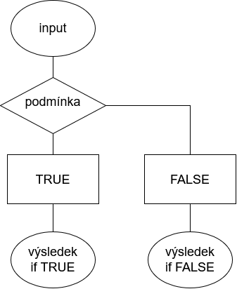

### Vrstvení `if ... else`

Je možné do sebe postupně jednotlivé `if ... else` podmínky vrstvit.

**Vrstvení s provádí zpravidla pro `FALSE`.**

Vrstevní je samozřejmě **možné provádět mnohokrát opakovaně**.

**Postoupnost podmínek**

`if ... else` a všechny podobné funkce fungují na podobném principu; **postupují po vrstvách podmínek tak dlouho, dokud nenarazí na `TRUE`, kdy se zastaví**.

Pokud nenarazí na `TRUE` podmínku, pokračují dokud se nedostanou k finální `FALSE` podmínce, pokud je určena.

### Schéma vrstvení `if ... else`

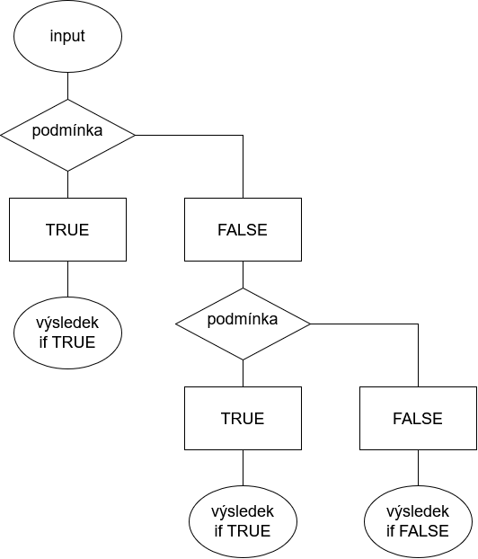

### Procvičení `if ... else`

1. Na dopravní hřiště mohou pouze děti ve věku 15 a více, mladší pouze s povolením rodičů. Může dítě na hřiště?
2. Frantovi je 53 let. Chce si koupit jízdenku, u které je možnost slevy pro seniory od 65 let, pro děti a studenty až do 26 let včetně.  
   Ověř, zda má Franta na tuto slevu nárok.

## Samostatné cvičení `if ... else`

Uzavírají se známky na konci semestru. Zápočet dostanou pouze ti, kteří mají dosavadní **hodnocení na lepším stupni než 5** a v posledním testu získali **jiný počet než nula bodů**. Pokud tyto podmínky nesplňují, tak zápočet mohou dostat i tehdy **pokud vypracovali seminární práci navíc a v posledním testu měli alespoň 50 bodů**.

Julie má dosavadní hodnocení sice na 5, ani test se jí nepovedl a měla pouze 17 bodů. Napsala ale velmi povedenou semestrální práci na téma kyberbezpečnosti ve Vietnamu.

**Dostane Julie zápočet?**

### Řešení

Dostane Julie zápočet?

Pro jednodušší práci s nimi si uložíme hodnoty do proměnných.

```r
znamka <- 5
pocetBodu <- 17
semestralka <- TRUE
```

Hodnoty si dosadíme do výpočtu. Pozor na formulaci zadání!

```r
if (znamka < 5 & pocetBodu != 0)
  {paste("Julie má známku", znamka, "a získala", pocetBodu, "bodů, má proto nárok na vyznamenání.")} else
  if (semestralka == TRUE & pocetBodu >= 50)
  {paste("Julie má počet bodů", pocetBodu, "a napsala seminárku, má proto nárok na vyznamenání.")} else
    {"Julie nemá právo na vyznamenání."}
```

```
[1] "Julie nemá právo na vyznamenání."
```

Julie zápočet nedostane.

### Potenciální zádrhely

Co se stane, když se pokusíme použít **`NA` hodnotu**?

Funkce nemá co porovnávat - nelze určit, jestli nic znamená `TRUE` nebo `FALSE`.

Co se stane, když se do funkce `if ... else` pokusíme vložit **hodnotu o více jak jednom prvku?**

**Nelze aplikovat na vektory**

R if potřebuje, aby výsledkem podmínky byla jedna logická hodnota TRUE/FALSE.

**Při aplikaci na více hodnot najednou tato podmínka není splněna.**

Jak takovou situaci vyřešíme?

## Funkce `ifelse`

> funkce umožňující aplikaci if … else funkce pro všechny jednotlivé hodnoty v prvku

`ifelse(podmínka, vyber pokud TRUE, vyber pokud FALSE)`

```r
x <- -1:5
ifelse(x > 0,"Kladné číslo", "Záporné")
```

```
[1] "Záporné"      "Záporné"      "Kladné číslo" "Kladné číslo" "Kladné číslo"
[6] "Kladné číslo" "Kladné číslo"
```

**I tuto funkci můžeme vrstvit.**

```r
x <- -1:5
ifelse(x > 0,"Kladné číslo", ifelse(x < 0, "Záporné", "Nula"))
```

```
[1] "Záporné"      "Nula"         "Kladné číslo" "Kladné číslo" "Kladné číslo"
[6] "Kladné číslo" "Kladné číslo"
```

### Funkce ve funkci

**Výsledkem nemusí být pouze text**

Nezapomeňte, že výsledkem nemusí být pouze pokyn “zobraz text”, ale **`ifelse` (stejně jako `if ... else`) mohou v reakci na podmínku spustit jakékoliv funkce**.

**Ukázka**

Zkontroluj, jestli je hodnota v `Sepal.Lenght` > 5. Pokud ano, zaokrouhli ji nahoru. Pokud ne, zaokrouhli dolu.

```r
iris %>%
  mutate(
    SL_zaokrouhlena = ifelse(
      Sepal.Length > 5,
      ceiling(Sepal.Length),
      floor(Sepal.Length))) %>%
  head()
```

```
  Sepal.Length Sepal.Width Petal.Length Petal.Width Species SL_zaokrouhlena
1          5.1         3.5          1.4         0.2  setosa               6
2          4.9         3.0          1.4         0.2  setosa               4
3          4.7         3.2          1.3         0.2  setosa               4
4          4.6         3.1          1.5         0.2  setosa               4
5          5.0         3.6          1.4         0.2  setosa               5
6          5.4         3.9          1.7         0.4  setosa               6
```

### Potenciální zádrhely

Funkce `ifelse` nám sice vyřeší problém aplikace na více než jednu hodnotu, ale… **stojí to za to**?

```r
pocetBoduA$Martin
```

```
[1] 20 55 46 NA 30
```

```r
pocetBoduA %>%
    mutate(Martin = ifelse(
        is.na(Martin), "neklasifikováno", ifelse(
          Martin < 50, "nedostatečný", ifelse(
            Martin < 75, "dobrý", ifelse(
              Martin < 90, "velmi dobrý", ifelse(
                Martin <= 100, "výborný"))))))
```

```
           Martin Ludmila Jana
1    nedostatečný      80   NA
2           dobrý      95   NA
3    nedostatečný      12    5
4 neklasifikováno      70   12
5    nedostatečný      69    3
```

**Funkce `ifelse` se stává při delším řetězení nepřehlednou.**

## funkce `dplyr::case_when`

> funkce umožňující přehlednější vrstvení podmínek než `ifelse`

`case_when(podmínka ~ výsledek pokud TRUE)`

```r
pocetBoduA$Martin
```

```
[1] 20 55 46 NA 30
```

```r
pocetBoduA %>%
    mutate(Martin = case_when(
        is.na(Martin) ~ "neklasifikováno",
        Martin < 50 ~ "nedostatečný",
        Martin < 75 ~ "dobrý",
        Martin < 90 ~ "velmi dobrý",
        .default =  "výborný")) #vychozi hodnota pokud ostatni neprojdou
```

```
           Martin Ludmila Jana
1    nedostatečný      80   NA
2           dobrý      95   NA
3    nedostatečný      12    5
4 neklasifikováno      70   12
5    nedostatečný      69    3
```

**Pozor na chybějící hodnoty!**

Dejte pozor na to, že pokud funkce narazí na jinak nezapracovanou **`NA` hodnotu, automaticky ji bere jako `.default`**.

```r
pocetBoduA %>%
    mutate(Martin = case_when(
        Martin < 50 ~ "nedostatečný",
        Martin < 75 ~ "dobrý",
        Martin < 90 ~ "velmi dobrý",
        .default = "výborný"))
```

```
        Martin Ludmila Jana
1 nedostatečný      80   NA
2        dobrý      95   NA
3 nedostatečný      12    5
4      výborný      70   12
5 nedostatečný      69    3
```

### Procvičení `ifelse`

1. Pokud je v `iris` sloupec `Sepal.Length` > 5, přičti 10, jinak odečti 10.
2. Vytvoř u `iris` sloupec `transformace`, kde budou odmocněné hodnoty `Petal.Length` pokud jsou větší než medián `Petal.Length`, jinak `NA`.

### Procvičení `case_when`

1. Přeměň názvy odrůd (species) v datasetu `iris` na jejich běžná jména.
2. Vytvoř v datasetu sloupec `status`

## Samostatné cvičení

Mějme data frame `data`. Vytvořme pro něj nový sloupec `z,` který bude naplněn za následujících podmínek:

- pokud je `x` sudé číslo , odmocni `x` a přidej k němu hodnotu `y`
- pokud je `x` liché číslo, umocni `(x / y)` na druhou

Nezapomeňte na chybějící hodnoty!

```r
data <- data.frame(
  x = c(4, 16, 25, NA, 81, 100),
  y = c(2, 4, 5, 6, 9, 10)); data
```

```
    x  y
1   4  2
2  16  4
3  25  5
4  NA  6
5  81  9
6 100 10
```

### Řešení

Mějme data frame `data`. Vytvořme pro něj nový sloupec `z,` který bude naplněn za následujících podmínek:

- pokud je `x` sudé číslo , odmocni `x` a přidej k němu hodnotu `y`
- pokud je `x` liché číslo, umocni `(x / y)` na druhou

Vytvoříme si data frame.

```r
data <- data.frame(
  x = c(4, 0, 25, NA, 81, 100, 9),
  y = c(2, 4, 5, 6, 9, 10, 3))
```

Vytvoříme si sloupec `z`.

```r
data %>%
  mutate(z = 1) #1 placeholder pro vysvetleni postupu
```

```
    x  y z
1   4  2 1
2   0  4 1
3  25  5 1
4  NA  6 1
5  81  9 1
6 100 10 1
7   9  3 1
```

Zkontrolujme, zda je `x` 0 a pokud ano, mějme `z` jako `NA`.

```r
data %>%
  mutate(
    z = case_when(
      x == 0 ~ NA)) #proc mame vsude NA?
```

```
    x  y  z
1   4  2 NA
2   0  4 NA
3  25  5 NA
4  NA  6 NA
5  81  9 NA
6 100 10 NA
7   9  3 NA
```

Zkontrolujme, zda je `x` sudé číslo a pokud ano, odmocněme ho a přičtěme `y`.

```r
data %>%
  mutate(
    z = case_when(
      x == 0 ~ NA,
      x %% 2 == 0 ~ sqrt(x) + y))
```

```
    x  y  z
1   4  2  4
2   0  4 NA
3  25  5 NA
4  NA  6 NA
5  81  9 NA
6 100 10 20
7   9  3 NA
```

```r
data %>%
  mutate(
    z = case_when(
      x == 0 ~ NA,
      x %% 2 == 0 ~ sqrt(x) + y,
      x %% 2 == 1 ~ (x / y)^2))
```

```
    x  y  z
1   4  2  4
2   0  4 NA
3  25  5 25
4  NA  6 NA
5  81  9 81
6 100 10 20
7   9  3  9
```

Určeme si co se zbylými hodnotami - stejně jako u 0 nemáme pokyny, proto `NA`.

```r
data %>%
  mutate(
    z = case_when(
      x == 0 ~ NA,
      x %% 2 == 0 ~ sqrt(x) + y,
      x %% 2 == 1 ~ (x / y)^2,
      .default = NA))
```

```
    x  y  z
1   4  2  4
2   0  4 NA
3  25  5 25
4  NA  6 NA
5  81  9 81
6 100 10 20
7   9  3  9
```

**Proč dáváme 0 jako první podmínku?**

**Nezapomeňte: jakmile hodnta splní jednu podmínku, další už se nekontrolují!**

## `for` cyklus

> cyklus (loop), který umožňuje opakovaně provést stejný kód

`for (hodnota in vektor hodnot) {proved´ příkaz}`

```r
# kazdou hodnotu v 1:10 nam umocni a zobraz
for (i in 1:10) {print(i^2)} #print fce vypise obsah
```

```
[1] 1
[1] 4
[1] 9
[1] 16
[1] 25
[1] 36
[1] 49
[1] 64
[1] 81
[1] 100
```

### Schéma `for` cyklu

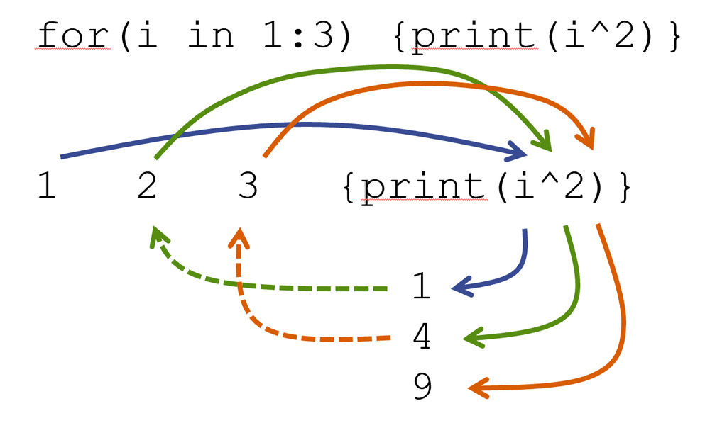

### Ukázka

**`i` je pouhý placeholder pro pojem “hodnota”**

Není nutné `i` používat, ale je to standardní.

```r
for (x in c(-8, 9, 11, 45)) {print(x+2)}
```

```
[1] -6
[1] 11
[1] 13
[1] 47
```

### Proč cykly potřebují `print`?

Samotný cyklus provádí pouze a jednu věc stále dokola - provádí `{příkaz}`.

```r
for (i in 1:3) {print(i^2)}
```

```
[1] 1
[1] 4
[1] 9
```

```r
for (i in 1:3) {i^2} #proc nic nevidime?
```

**Výpočet neznamená zobrazení**

**R po vypočítání automaticky výsledek “zahazuje”**, pokud mu neřekneme ať ho zobrazí.

Jeden ze způsobů, jak si o zobrazení řekneme, je třeba zavoláním jména proměnné a nebo právě použití funkce `print`.

```r
a <- "kolo"
a
```

```
[1] "kolo"
```

```r
print("kolo")
```

```
[1] "kolo"
```

### Co všechno může vzniknout v `for` cyklu?

Ukázali jsme si, že výsledkem může být zobrazení určitých hodnot. **Ale co kdybychom si je chtěli ukládat?**

```r
x <- c(2, 4, 6, 8)
vysledek <- NULL; vysledek
```

```r
for (i in 1:length(x)) {vysledek[i] <- x[i] * 2}

vysledek
```

```
[1]  4  8 12 16
```

**Co se děje?**

Máme prázdnou proměnou `vysledek`, kam si uložíme tolik hodnot jako je délka `x`, kdy každá hodnota bude korespondovat s hodnotou `x` na totožné pozici * 2.

### K čemu to ale vůbec je?

Výpočty, které jsme si zatím u `for` cyklu ukázaly, by šly provést i jednoduše pomocí funkcí jako `ifelse`. **Proč tedy vůbec s cykly pracovat?**

**Cyklus umožňuje postupně pracovat s daty**

Pomocí této funkce je možné nejenom měnit hodnoty, ale **měnit je v závislosti na změně provedené na předchozí hodnotě**.

1. Máme buněčný vzorek, ve kterém se buňky množí rychlostí 5 % za jednu hodinu. Začínáme s 1000 buňkami, kolik jich budeme mít po deseti hodinách?

```r
mnozstviBunek <- c(1000, rep(0, 9)); mnozstviBunek
```

```
 [1] 1000    0    0    0    0    0    0    0    0    0
```

```r
for (i in 2:length(mnozstviBunek)) {
  mnozstviBunek[i] <- mnozstviBunek[i - 1] * 1.05
}

mnozstviBunek
```

```
 [1] 1000.000 1050.000 1102.500 1157.625 1215.506 1276.282 1340.096 1407.100
 [9] 1477.455 1551.328
```

```r
mnozstviBunek[10]
```

```
[1] 1551.328
```

2. Pomocí modelu SIR namodelujme, jak se bude během 100 dnů epidemie vyvíjet počet nakažených, uzdravených a osob ohrožených nakažením.

```r
N <- 1000 #velikost populace

S <- NULL #Susceptible (ohrozeni)
I <- NULL #Infected (nakazeni)
R <- NULL #Recovered (uzdraveni)

#pocatecni hodnoty
S[1] <- 990
I[1] <- 10
R[1] <- 0

beta <- 0.3 #mira prenosu infekce - jak rychle?
gamma <- 0.1 #mira uzdravovani - jak rychle se I stanou R?
dt <- 1 #casova jednotka - jeden den

for (t in 1:100) { #chceme provest simulaci za 100 dnu

  nove_nakazy <- beta * S[t] * I[t] / N * dt #rovnice nakazlivosti
  nova_uzdraveni <- gamma * I[t] * dt #rovnice uzdravovani
  #proc musi byt v cyklu? protoze se kazdy den meni

  #vypocet vyvoje
  S[t + 1] <- S[t] - nove_nakazy
  I[t + 1] <- I[t] + nove_nakazy - nova_uzdraveni
  R[t + 1] <- R[t] + nova_uzdraveni
}
```

A můžeme se na výsledky rovnou i podívat a zobrazit si je ve grafu.

```r
S
```

```
  [1] 990.00000 987.03000 983.48558 979.26128 974.23474 968.26496 961.19099
  [8] 952.83110 942.98296 931.42526 917.92128 902.22523 884.09192 863.29050
 [15] 839.62240 812.94344 783.18877 750.39867 714.74143 676.52912 636.22118
 [22] 594.41201 551.80093 509.14626 467.20935 426.69692 388.21139 352.21630
 [29] 319.02104 288.78399 261.53036 237.17862 215.57005 196.49671 179.72517
 [36] 165.01485 152.13095 140.85278 130.97836 122.32639 114.73647 108.06813
 [43] 102.19924  97.02414  92.45177  88.40375  84.81270  81.62066  78.77779
 [50]  76.24113  73.97364  71.94327  70.12227  68.48654  67.01512  65.68971
 [57]  64.49432  63.41491  62.43917  61.55624  60.75653  60.03157  59.37383
 [64]  58.77663  58.23404  57.74073  57.29196  56.88350  56.51154  56.17265
 [71]  55.86378  55.58214  55.32524  55.09085  54.87691  54.68159  54.50322
 [78]  54.34030  54.19145  54.05543  53.93112  53.81749  53.71360  53.61860
 [85]  53.53173  53.45227  53.37960  53.31311  53.25229  53.19664  53.14572
 [92]  53.09912  53.05647  53.01745  52.98173  52.94903  52.91911  52.89172
 [99]  52.86664  52.84369  52.82267
```

```r
I
```

```
  [1]  10.000000  11.970000  14.317425  17.109976  20.425520  24.352743
  [7]  28.991442  34.452191  40.855108  48.327298  56.998548  66.994748
 [13]  78.428578  91.387142 105.916523 122.003837 139.558119 158.392412
 [19] 178.210408 198.601676 219.049453 238.953678 257.669391 274.557114
 [25] 289.038322 300.646911 309.067754 314.156065 315.935725 314.579195
 [31] 310.374907 303.689154 294.928812 284.509276 272.829889 260.257220
 [37] 247.115389 233.682020 220.188247 206.821391 193.729166 181.024590
 [43] 168.791028 157.087019 145.950687 135.403638 125.454331 116.100934
 [49] 107.333711  99.136994  91.490790  84.372083  77.755875  71.616013
 [55]  65.925832  60.658657  55.788186  51.288774  47.135638  43.305008
 [61]  39.774215  36.521756  33.527318  30.771780  28.237200  25.906790
 [67]  23.764874  21.796848  19.989127  18.329099  16.805068  15.406199
 [73]  14.122472  12.944624  11.864100  10.873010   9.964075   9.130590
 [79]   8.366378   7.665756   7.023494   6.434780   5.895193   5.400669
 [85]   4.947475   4.532182   4.151640   3.802960   3.483488   3.190791
 [91]   2.922633   2.676968   2.451914   2.245750   2.056894   1.883898
 [97]   1.725433   1.580282   1.447329   1.325551   1.214010
```

```r
R
```

```
  [1]   0.000000   1.000000   2.197000   3.628742   5.339740   7.382292
  [7]   9.817566  12.716711  16.161930  20.247441  25.080170  30.780025
 [13]  37.479500  45.322358  54.461072  65.052724  77.253108  91.208920
 [19] 107.048161 124.869202 144.729369 166.634315 190.529683 216.296622
 [25] 243.752333 272.656165 302.720856 333.627632 365.043238 396.636811
 [31] 428.094730 459.132221 489.501136 518.994017 547.444945 574.727934
 [37] 600.753656 625.465195 648.833397 670.852222 691.534361 710.907277
 [43] 729.009736 745.888839 761.597541 776.192610 789.732974 802.278407
 [49] 813.888500 824.621871 834.535571 843.684650 852.121858 859.897445
 [55] 867.059047 873.651630 879.717496 885.296314 890.425192 895.138755
 [61] 899.469256 903.446678 907.098853 910.451585 913.528763 916.352483
 [67] 918.943162 921.319650 923.499334 925.498247 927.331157 929.011664
 [73] 930.552284 931.964531 933.258993 934.445403 935.532704 936.529112
 [79] 937.442171 938.278809 939.045384 939.747734 940.391212 940.980731
 [85] 941.520798 942.015545 942.468764 942.883928 943.264224 943.612572
 [91] 943.931651 944.223915 944.491612 944.736803 944.961378 945.167067
 [97] 945.355457 945.528000 945.686029 945.830762 945.963317
```

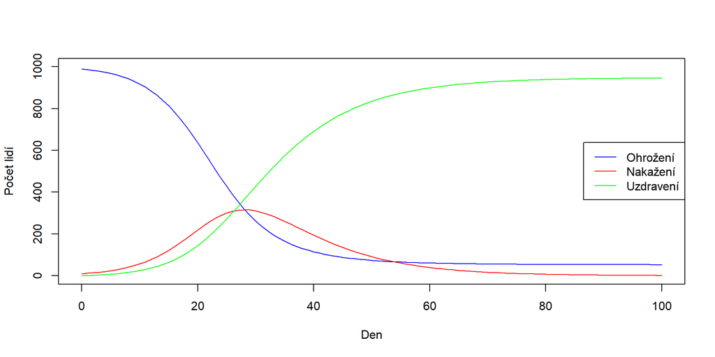

```r
plot(0:100, S, type = "l", col = "blue",
     ylim = c(0, 1000),
     xlab = "Den", ylab = "Počet lidí")

lines(0:100, I, col = "red")
lines(0:100, R, col = "green")

legend("right",
       legend = c("Ohrožení", "Nakažení", "Uzdravení"),
       col = c("blue", "red", "green"),
       lty = 1)
```

## Procvičení `for` cyklu

1. Radioaktivní látka má na začátku hmotnost 100 gramů. Každý rok se rozloží 10 % zbývajícího množství. Jaká bude váha po deseti letech?
2. Ve vesnici žije 500 obyvatel. Kvůli masivnímu přistěhování se ale počet obyvatel každý rok zvětší o dvojnásobek. Kolik bude v obci bydlet lidí za pět let?

## Samostatné cvičení `for` cyklu

Provádíte predikci teploty vzduchu. Máme naměřenou teplotu v **7:00 ráno, kdy bylo 10 stupňů Celsia**. Víte, že **každou hodinu teplota stoupne o 1,5 stupně**. Jaká teplota bude během dalších **pět hodin**?

### Řešení

Provádíte předpověd´ teploty vzduchu. Máme naměřenou teplotu v **7:00 ráno, kdy bylo 10 stupňů Celsia**. Víte, že **každou hodinu teplota stoupne o 1,5 stupně**. Jaká teplota bude během dalších **pět hodin**?

Vytvoříme si proměnnou která bude obsahovat počáteční hodnotu.

```r
sedmRano <- 10
```

Vytvoříme cyklus, kde se pětkrát k předchozí hodnotě přičte 1.5.

```r
for (i in 1:5) {
  sedmRano <- sedmRano + 1.5
  print(sedmRano) #zobrazime si vysledek
}
```

```
[1] 11.5
[1] 13
[1] 14.5
[1] 16
[1] 17.5
```

Můžeme samozřejmě provést i variantu s uložením výsledků.

```r
sedmRano <- 10
teplota <- NULL

for (i in 1:5) {
  sedmRano <- sedmRano + 1.5
  teplota[i] <- sedmRano}

teplota
```

```
[1] 11.5 13.0 14.5 16.0 17.5
```

### Aplikace `for` cyklu na jednotlivé prvky proměnné

Pomocí cyklu můžeme nejenom opakovaně spouštět kód na jednotlivých hodnotách, ale na základě totožného principu i **spouštět kód na jednotlivých částech data frame.**

```r
mtcars %>% head()
```

```
                   mpg cyl disp  hp drat    wt  qsec vs am gear carb
Mazda RX4         21.0   6  160 110 3.90 2.620 16.46  0  1    4    4
Mazda RX4 Wag     21.0   6  160 110 3.90 2.875 17.02  0  1    4    4
Datsun 710        22.8   4  108  93 3.85 2.320 18.61  1  1    4    1
Hornet 4 Drive    21.4   6  258 110 3.08 3.215 19.44  1  0    3    1
Hornet Sportabout 18.7   8  360 175 3.15 3.440 17.02  0  0    3    2
Valiant           18.1   6  225 105 2.76 3.460 20.22  1  0    3    1
```

```r
prumery <- NULL

for (i in 1:length(mtcars)) {
  prumery[i] <- mean(mtcars[,i])
}

print(prumery)
```

```
 [1]  20.090625   6.187500 230.721875 146.687500   3.596563   3.217250
 [7]  17.848750   0.437500   0.406250   3.687500   2.812500
```

Není to ale zbytečně komplikované? **Nebylo by to jednodušší, kdybychom mohli rovnou použít jednu funkci…?**

[figure not shown]

## Rodina `apply` funkcí

> funkce `apply` umožňují aplikovat stejnou funkci na více prvků zároveň

| Funkce | K čemu slouží | Typický vstup |
| --- | --- | --- |
| `apply` | Výpočet po řádcích nebo sloupcích | Matice, array, data frame |
| `lapply` | Použití funkce na každý prvek a vrácení seznamu | Seznam |
| `sapply` | Podobně jako `lapply`, ale pokusí se zjednodušit výsledek | Vektor či matice, případně array |
| `vapply` | Podobně jako `sapply`, ale s předem určeným typem výsledku | Seznam, vektor |
| `tapply` | Výpočet ve skupinách podle kategorií | Vektor a skupiny |
| `mapply` | Současné procházení více vstupů | Několik vektorů či seznamů |
| `rapply` | Rekurzivní použití funkce na prvky vnořeného seznamu | Vnořený seznam |

### `apply` funkce

#### Syntax

`apply(data, MARGIN = směr (řádky/sloupce), FUN = funkce co má být aplikována)`

**MARGIN**

- 1 = řádky
- 2 = sloupce

**FUN**

- vždy se zapisuje bez závorek!

#### Ukázky použití `apply` funkce

**Průměrné hodnoty všech parametrů v datasetu `mtcars`:**

```r
head(mtcars)
```

```
                   mpg cyl disp  hp drat    wt  qsec vs am gear carb
Mazda RX4         21.0   6  160 110 3.90 2.620 16.46  0  1    4    4
Mazda RX4 Wag     21.0   6  160 110 3.90 2.875 17.02  0  1    4    4
Datsun 710        22.8   4  108  93 3.85 2.320 18.61  1  1    4    1
Hornet 4 Drive    21.4   6  258 110 3.08 3.215 19.44  1  0    3    1
Hornet Sportabout 18.7   8  360 175 3.15 3.440 17.02  0  0    3    2
Valiant           18.1   6  225 105 2.76 3.460 20.22  1  0    3    1
```

```r
apply(mtcars, 2, mean)
```

```
       mpg        cyl       disp         hp       drat         wt       qsec
 20.090625   6.187500 230.721875 146.687500   3.596563   3.217250  17.848750
        vs         am       gear       carb
  0.437500   0.406250   3.687500   2.812500
```

**Počet ne/přijatého studentstva**

```r
str(UCBAdmissions)
```

```
 'table' num [1:2, 1:2, 1:6] 512 313 89 19 353 207 17 8 120 205 ...
 - attr(*, "dimnames")=List of 3
  ..$ Admit : chr [1:2] "Admitted" "Rejected"
  ..$ Gender: chr [1:2] "Male" "Female"
  ..$ Dept  : chr [1:6] "A" "B" "C" "D" ...
```

```r
head(UCBAdmissions)
```

```
, , Dept = A

          Gender
Admit      Male Female
  Admitted  512     89
  Rejected  313     19

, , Dept = B

          Gender
Admit      Male Female
  Admitted  353     17
  Rejected  207      8

, , Dept = C

          Gender
Admit      Male Female
  Admitted  120    202
  Rejected  205    391

, , Dept = D

          Gender
Admit      Male Female
  Admitted  138    131
  Rejected  279    244

, , Dept = E

          Gender
Admit      Male Female
  Admitted   53     94
  Rejected  138    299

, , Dept = F

          Gender
Admit      Male Female
  Admitted   22     24
  Rejected  351    317
```

```r
apply(UCBAdmissions, 1, sum)
```

```
Admitted Rejected
    1755     2771
```

### `sapply` funkce

#### Syntax

`sapply(data, FUN = funkce co má být aplikována)`

Funkce `sapply` je defacto totožná s `lapply`, pouze se snaží vrátit co nejjednodušší strukturu.

```r
vzorky <- list(
  vzorek_A = c(10, 12, 11, 13),
  vzorek_B = c(8, 9, 7, 10),
  vzorek_C = c(15, 16, 14, 17)
)

sapply(vzorky, mean)
```

```
vzorek_A vzorek_B vzorek_C
    11.5      8.5     15.5
```

```r
unlist(lapply(vzorky, mean))
```

```
vzorek_A vzorek_B vzorek_C
    11.5      8.5     15.5
```

```r
lapply(vzorky, mean)
```

```
$vzorek_A
[1] 11.5

$vzorek_B
[1] 8.5

$vzorek_C
[1] 15.5
```

```r
sapply(vzorky, mean, simplify = FALSE, USE.NAMES = FALSE)
```

```
$vzorek_A
[1] 11.5

$vzorek_B
[1] 8.5

$vzorek_C
[1] 15.5
```

### Procvičení `apply`

**Máme teploty naměřené během tří dnů na čtyřech stanicích.**

Jaké byly průměrné hodnoty a maxima pro každou ze stanic a jaké byly průměrné hodnoty pro každý den?

**V laboratoři byly sledovány tři bakteriální kultury. V každé kultuře bylo provedeno několik měření počtu bakterií.**

Jaký je průměrný a nejvyšší počet bakterií v každé kultuře?

## Samostatné cvičení `apply`

**V laboratoři jsme naměřili koncentraci látky ve čtyřech vzorcích.**

1. Vypočítejte průměrnou a nejvyší koncentraci každého vzorku.
2. Zjistěte počet měření v každém vzorku.

```r
vzorky <- list(
  A = c(10, 12, 14, 15, 18),
  B = c(8, 9, 11),
  C = c(15, 17, 16, 20, 11, 13),
  D = c(20, 22, 21, 24))
```

### Řešení

**V laboratoři jsme naměřili koncentraci látky ve čtyřech vzorcích.**

1. Vypočítejte průměrnou a nejvyší koncentraci každého vzorku.

```r
#prumerne koncentrace
sapply(vzorky, mean)
```

```
        A         B         C         D
13.800000  9.333333 15.333333 21.750000
```

```r
#maximalni koncentrace
sapply(vzorky, max)
```

```
 A  B  C  D
18 11 20 24
```

2. Zjistěte počet měření v každém vzorku.

```r
#pocet mereni
sapply(vzorky, length)
```

```
A B C D
5 3 6 4
```

## Příprava na příští hodinu

1. Stáhněte si soubor newborns.txt a uložte si ho do jasně pojmenované složky pro šestou hodinu.
2. **Do páteční půlnoci** mi pošlete ukázku typického datasetu, pro který potřebujete vytvářet vizualizace - **NEZAPOMEŇTE NA POPISKY SLOUPCŮ!** Není to povinné, ale pomůže mi to s tvorbou průběžných procvičování a obsahu pro vaše samostudium.

## Domácí úkol

**1. Byla naměřena následující koncentrace látky:**

```r
koncentrace <- c("vzorek1" = "75 mg/l",
                 "vzorek2" = "101 mg/l",
                 "vzorek3" = "158 mg/l",
                 "vzorek4" = "48 mg/l")
```

- Pokud je koncentrace vyšší než 100 mg/l, vypište „Vysoká koncentrace“.
- Pokud je koncentrace mezi 50 a 100 mg/l včetně, vypište „Normální koncentrace“.
- Jinak vypište „Nízká koncentrace“.

**2. V laboratorní kultuře je na začátku 200 bakterií. Počet bakterií se každou hodinu zvýší o 30 %. Kolik jich bude po osmi hodinách?**

**3. Během pokusu jsme čtyři vzorky vystavily třem látkám a změřili jejich reaktivitu.**

```r
mereni <- matrix(
  c(12, 15, 18, 20, 25, 30,
  8,  10, 12, 35, 40, 45),
  nrow = 4, byrow = TRUE)

rownames(mereni) <- c("Vzorek 1", "Vzorek 2",
                      "Vzorek 3", "Vzorek 4")
colnames(mereni) <- c("Latka A", "Latka B", "Latka C")
```

- Jaká je průměrná reaktivita každého vzorku?
- Jaké byly nejvyšší hodnoty způsobené reaktivity pro každou látku a která látka způsobila největší reaktivitu?

**4. U pacientů byly naměřeny následující hodnoty glukózy v krvi (mmol/l):**

```r
c(8.5, 3.9, 5.9, 4.0, 4.5, 9.0, 6.3, 5.1, 7.0, 4.8, 7.2, 4.2)
```

```
 [1] 8.5 3.9 5.9 4.0 4.5 9.0 6.3 5.1 7.0 4.8 7.2 4.2
```

Množství cukru v krvi se dělí dle následující tabulky:

| Stav | Hodnoty |
| --- | --- |
| Norma nalačno | 3.9 - 5.5 |
| Prediabetes | 5.6 - 6.9 |
| Cukrovka | ≥ 7.0 |

Vytvořte přehlednou tabulku, kdy pro každého pacienta napíšete jejich ID dle pořadí, jejich naměřenou hodnotu a stav podle tabulky.

**Skript** s výpočtem zašlete nejpozději do pátku před příští hodinou na lucie.hoskova@ruk.cuni.cz

## Závěrečný projekt

Dva měsíce jsme si ukazovali, jak se má správně pracovat se skriptem, **co dělat a co nedělat.**

Vyzkoušeli jsme si, jaké to je pracovat s datasetem, který jsme sami nevytvořili, a že **je potřeba nad věcmi přemýšlet**.

Nyní si to dáme dohromady a půjdeme na to z trochu druhé strany. V průbehu týdne vám bude zaslán dataset, zadání a i očekávaný výsledek.

**Vaším úkolem bude napsat skript, který provede zadání a dostane se i ke správným výsledkům - ale bude porušovat snad všechna pravidla, které jsme se naučili.**

**Čím odpornější tím lepší!**

## Podmínky

### Termín odevzdání:

- Do **27.11. mi pošlete verzi skriptu**, která bude funkční a docházet stejných výsledků jako bylo očekáváno.
- V případě, že naleznu nějaké významné chyby (skript nelze spustit/výsledky jsou jiné/výsledky jsou stejné ale vyšlo vám to jen náhodou) tak vám skript vrátím k **opravě, která má deadline 4.12.**.

### Podoba:

Musí se stále jednat o **skript, který půjde spustit, a který dosáhne správných výsledků**. Doporučuji nepoužívat diakritiku (i když by vás to mohlo lákat), může se pak stát že se skript nespustí.

### Hodnocení:

Cílem je projet si všechny věci co jsme se naučili a zapřemýšlet o nich tak, že co je optimum? a co je přesným opakem toho jak toho tedy dosáhnout?

**Hodnotit budu snahu (a funkčnost), nikoliv nějakou arbitrální ohyzdnost.**

Autorstvo nejohyzdnějšího skriptu se ale může těšit na odměnu :].

### Výpomoc:

Pokud se na něčem zaseknete, **ozvěte se**. Narozdíl od domácích úkolů zde opravdu očekávám skript dotáhnutý dokonce, nikoliv pouze to, co jste v tu chvíli věděli jak na to.

## NENECHÁVEJTE TO NA POSLEDNÍ CHVÍLI

[figure not shown]

Pokud nestíháte, ozvěte se a nějak se domluvíme.

## Tipy navíc pro samostudium

### Alternativa funkce `apply` pro specifické sloupce

Funkce `apply`, se kterou jsme se během této hodiny seznámili, **umí samozřejmě aplikovat jiné funkce i na pouhé části datasetu**.

```r
apply(iris[,c("Sepal.Width", "Sepal.Length")],2,mean)
```

```
 Sepal.Width Sepal.Length
    3.057333     5.843333
```

**Existuje ovšem mnohem elegantnější způsob**, jak aplikovat funkce na jednotlivé sloupce, a to pomocí funkce `across`.

```r
iris %>%
  summarise(across(starts_with("Sepal"), mean))
```

```
  Sepal.Length Sepal.Width
1     5.843333    3.057333
```

Funkce `across` umožňuje aplikaci funkcí na specifické sloupce, přičemž obsahuje funkční podargumenty jako `starts_with` a `ends_with`, které používání této funkce mohou ještě urychlit.

`across` je třeba používat vždy uvnitř funkcí jako jsou `summarise`, `mutate` či `filter`.

### Tvorba vlastních funkcí

R taktéž umožňuje tvorbu vlastní funkce.

1. Pro vytvoření funkce je potřeba definovat, že se jedná o funkci, pomocí `function`.
2. Dovnitř `function` se vloží definice toho, na co bude funkce aplikována.
3. V zobáčkových závorkách se poté definuje, co přesně se má s touto funkcí provést.

Můžeme vytvářet i rozsáhlejší funkce. Co třeba tuto, kterou **můžeme aplikovat kdykoliv, kdy ji budeme potřebovat**.

```r
#vytvoreni fce
tlakHodnoty <- function(tlak) {
  case_when(
    is.na(tlak) ~ NA_character_,
    tlak < 90 ~ "Nízký",
    tlak < 120 ~ "Optimální",
    tlak < 130 ~ "Normální",
    tlak < 140 ~ "Vyšší normální",
    tlak < 160 ~ "Hypertenze 1. stupně",
    tlak < 180 ~ "Hypertenze 2. stupně",
    tlak >= 180 ~ "Hypertenze 3. stupně")
}
```

**Takto vytvořenou funkci, která nám určuje dignózu tlaku z hodnot, můžeme aplikovat na naměřené pacienty jak je třeba.**

```r
#pacienti
pacienti1A <- data.frame(
  jmeno = c("Anna", "Petr", "Jana", "Karel"),
  tlak = c(118, 145, 165, 85))

pacienti1B <- data.frame(
  jmeno = c("Jakub", "Felix", "Hana", "Eva"),
  tlak = c(132, 175, NA, 95))

#pridani diagnozy
pacienti1A <- pacienti1A %>%
  mutate(
    diagnoza = tlakHodnoty(tlak)); pacienti1A
```

```
  jmeno tlak             diagnoza
1  Anna  118            Optimální
2  Petr  145 Hypertenze 1. stupně
3  Jana  165 Hypertenze 2. stupně
4 Karel   85                Nízký
```

```r
pacienti1B <- pacienti1B %>%
  mutate(
    diagnoza = tlakHodnoty(tlak)); pacienti1B
```

```
  jmeno tlak             diagnoza
1 Jakub  132       Vyšší normální
2 Felix  175 Hypertenze 2. stupně
3  Hana   NA                 <NA>
4   Eva   95            Optimální
```

### Co dělá funkce `ifelse` s hodnotami?

**`ifelse` mění hodnoty na jejich atomické podoby** - atomická podoba faktoru je integer, takže pozor na případnou potřebu faktorizace.

```r
str(iris) #jaka je struktura iris pred upravou
```

```
'data.frame':   150 obs. of  5 variables:
 $ Sepal.Length: num  5.1 4.9 4.7 4.6 5 5.4 4.6 5 4.4 4.9 ...
 $ Sepal.Width : num  3.5 3 3.2 3.1 3.6 3.9 3.4 3.4 2.9 3.1 ...
 $ Petal.Length: num  1.4 1.4 1.3 1.5 1.4 1.7 1.4 1.5 1.4 1.5 ...
 $ Petal.Width : num  0.2 0.2 0.2 0.2 0.2 0.4 0.3 0.2 0.2 0.1 ...
 $ Species     : Factor w/ 3 levels "setosa","versicolor",..: 1 1 1 1 1 1 1 1 1 1 ...
```

```r
iris <- iris %>%
  mutate(Species =
           ifelse(Species == "setosa", "setosa", "invasiveSpecies"))

str(iris) #a struktura po uprave
```

```
'data.frame':   150 obs. of  5 variables:
 $ Sepal.Length: num  5.1 4.9 4.7 4.6 5 5.4 4.6 5 4.4 4.9 ...
 $ Sepal.Width : num  3.5 3 3.2 3.1 3.6 3.9 3.4 3.4 2.9 3.1 ...
 $ Petal.Length: num  1.4 1.4 1.3 1.5 1.4 1.7 1.4 1.5 1.4 1.5 ...
 $ Petal.Width : num  0.2 0.2 0.2 0.2 0.2 0.4 0.3 0.2 0.2 0.1 ...
 $ Species     : chr  "setosa" "setosa" "setosa" "setosa" ...
```